# gomez2

Andres Gomez

2023-01-23

## I. Introduction of the Data Set

### Breast Cancer Wisconsin Diagnostic Dataset from UCI Machine Learning Repository

In this report, we provide summary statistics and visualizations for the brca data set that is located within the R base Package. The brca data set represents biopsy features for the classification between malignant (M) and benign (B) of breast masses. It includes data for the mean, standard error (se), and worst value of 10 nuclear measurements.

The following sample presents the first 6 rows of the predictors (x) along with its outcomes (y). Said outcomes are divided into benign (B) and malignant (M):

#### Data from X ():

This data contains variables such as radius, texture, perimeter, area, smoothness, compactness, concavity, number of concave portions (concave_pts), symmetry, and the fractal dimension of the nucleus (fractal_dim):

```
##   x.radius_mean x.texture_mean x.perimeter_mean x.area_mean x.smoothness_mean
## 1        13.540          14.36            87.46       566.3           0.09779
## 2        13.080          15.71            85.63       520.0           0.10750
## 3         9.504          12.44            60.34       273.9           0.10240
## 4        13.030          18.42            82.61       523.8           0.08983
## 5         8.196          16.84            51.71       201.9           0.08600
## 6        12.050          14.63            78.04       449.3           0.10310
##   x.compactness_mean x.concavity_mean x.concave_pts_mean x.symmetry_mean
## 1            0.08129          0.06664           0.047810          0.1885
## 2            0.12700          0.04568           0.031100          0.1967
## 3            0.06492          0.02956           0.020760          0.1815
## 4            0.03766          0.02562           0.029230          0.1467
## 5            0.05943          0.01588           0.005917          0.1769
## 6            0.09092          0.06592           0.027490          0.1675
##   x.fractal_dim_mean
## 1            0.05766
## 2            0.06811
## 3            0.06905
## 4            0.05863
## 5            0.06503
## 6            0.06043
```

Note that the previous summary only presents the mean of the 10 nuclear measurements as a sample of the data that the user may encounter in the brca data set.

#### Data from y:

The y data, inside the brca data set, contains the outcomes. It contains whether the mass is malignant (M) or benign (B). The following are the first 6 items inside y.

```
## [1] B B B B B B
## Levels: B M
```

## II. Descriptive Statistics and Visualizations for Predictors:

In this section, the report will provide statistics of two variables considered to better contribute in predicting whether a tumor is benign or malignant, the variables for radius and compactness.

The following are histograms and density graphs displaying data for the variables previously mentioned in the report. We will look at the worst values, mean, and standard error for both of the values.

### Histograms & Statistics:

#### Worst Values:

- Radius Worst Value:

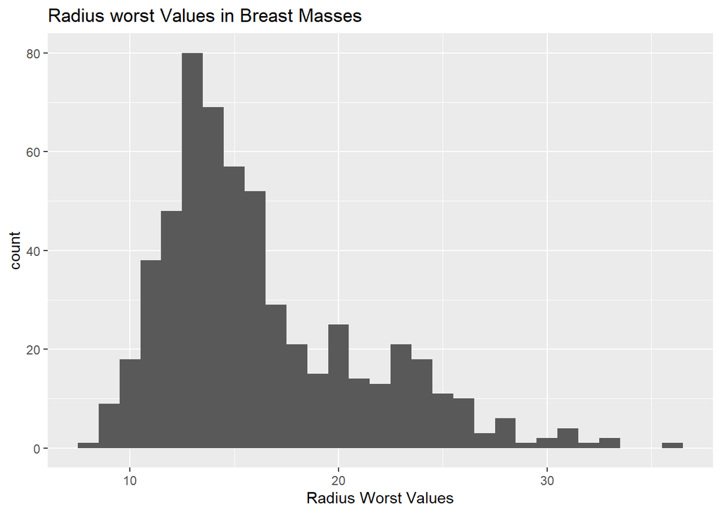

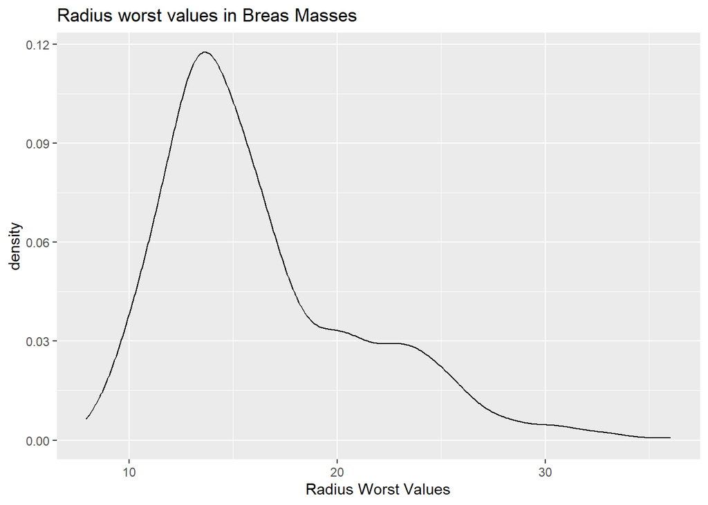

- Compactness Worst Value:

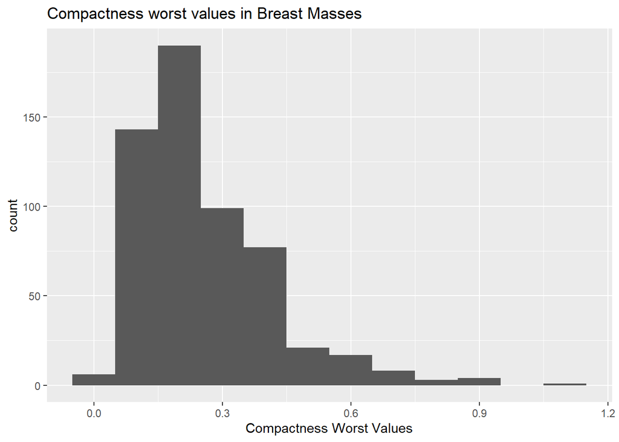

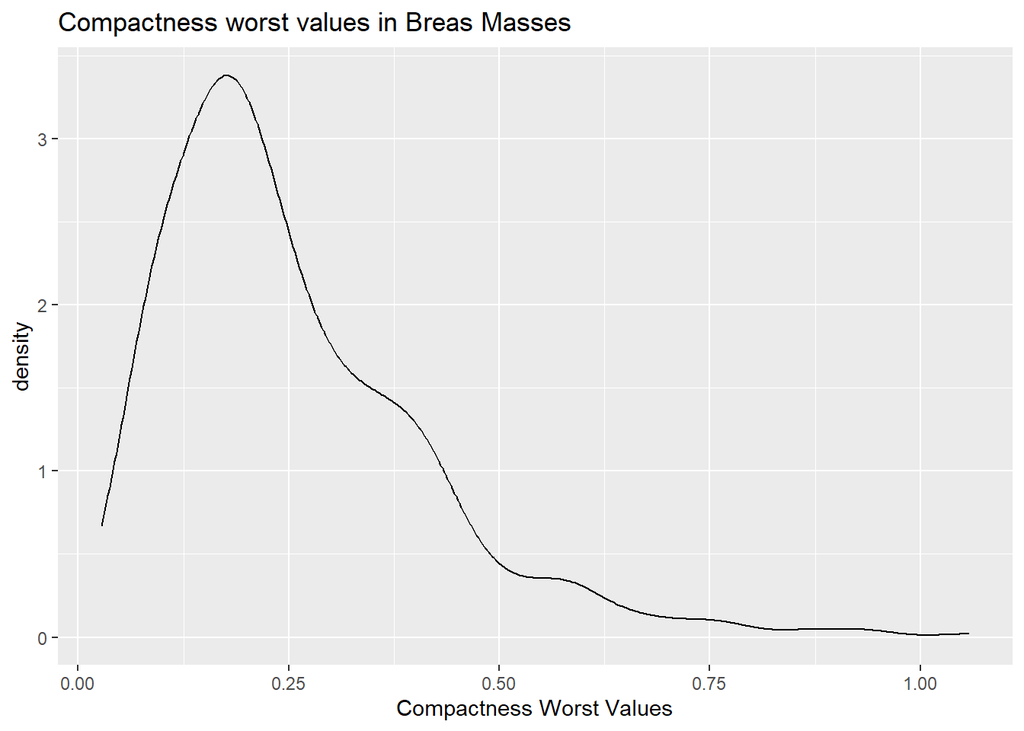

#### Mean:

- Radius Mean:

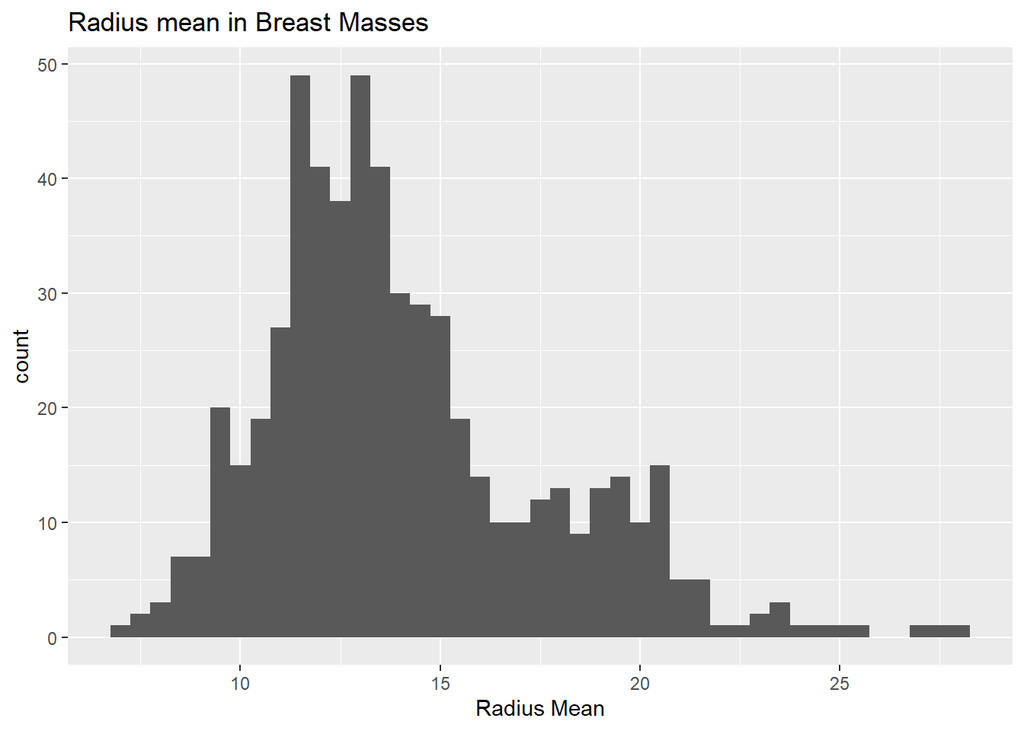

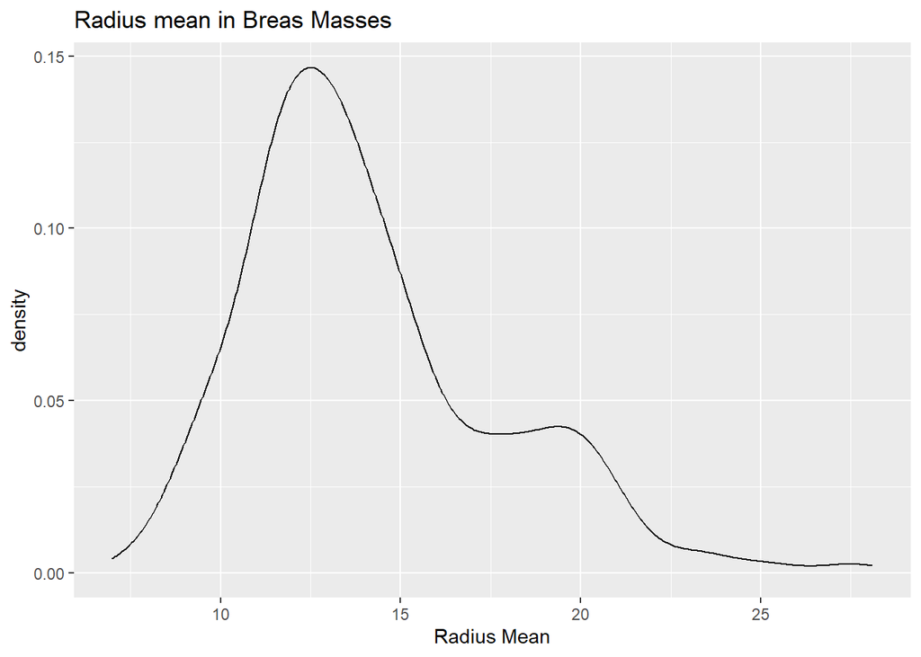

- Compactness Mean:

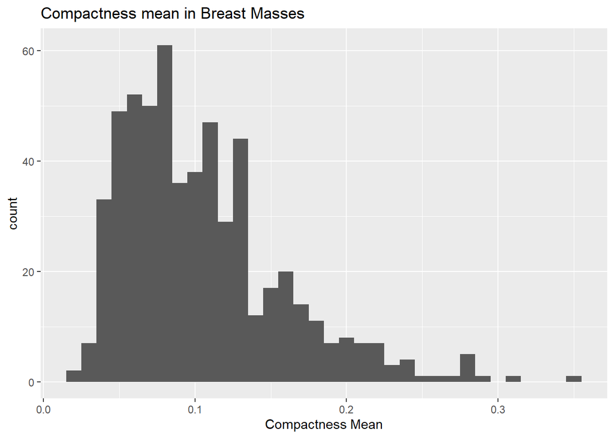

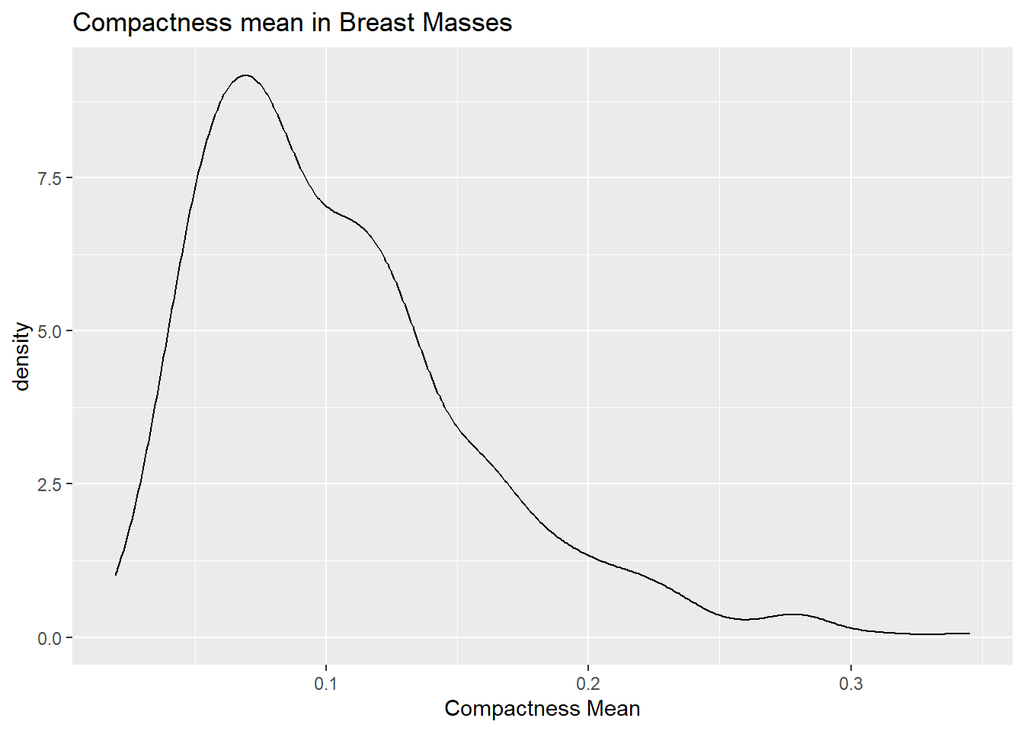

#### Standard Error:

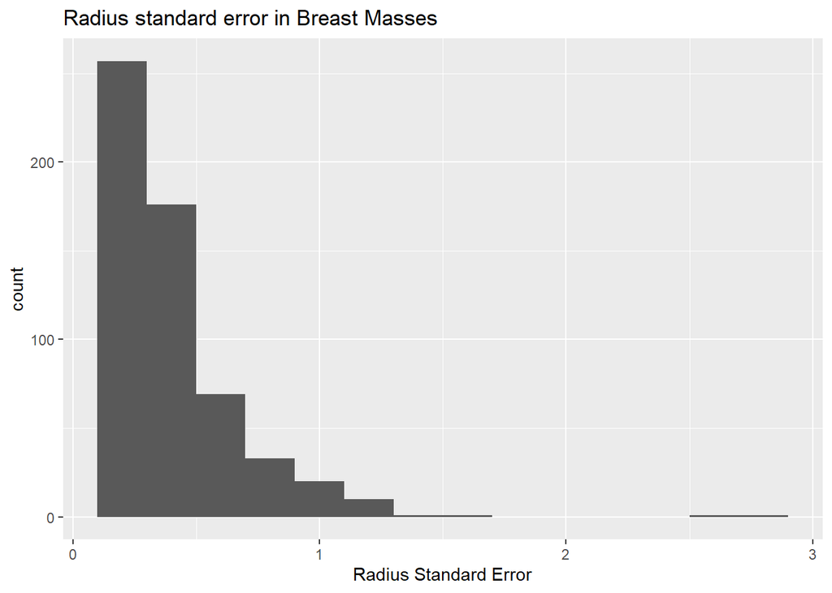

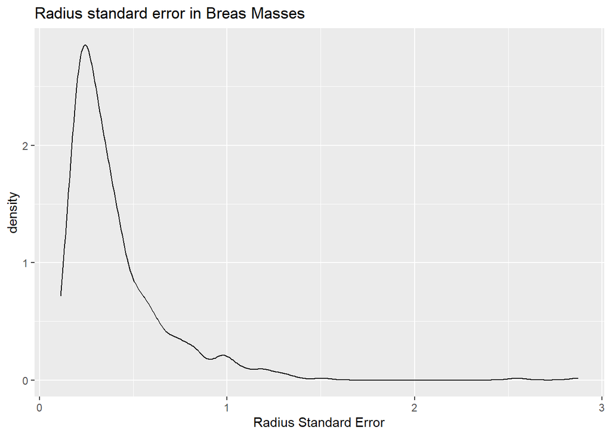

[figure not shown]

[figure not shown]

## III Visualization of Predictors with y

In this section we will present the two variables of radius and compactness separating the data by benign and malignant tumors.

### Scatter Plot for Radius:

- Radius Scatter Plot using the Radius Worst Values and Mean:

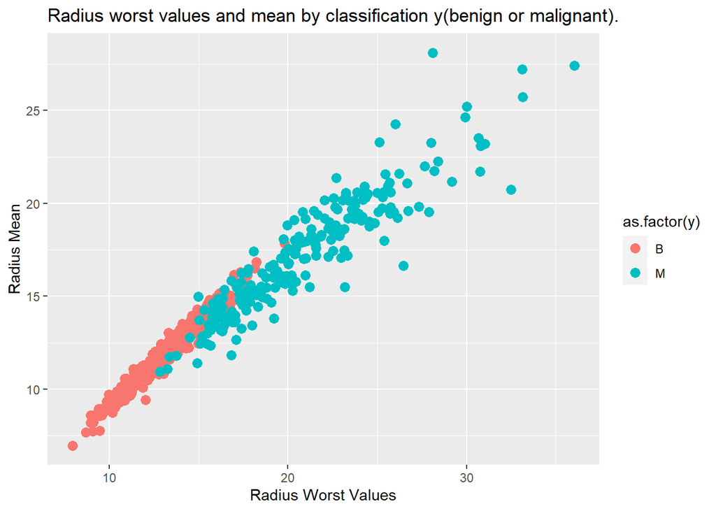

### Scatter Plot for compactness:

- Compactness Scatter Plot using the Compactness Worst Values and Mean:

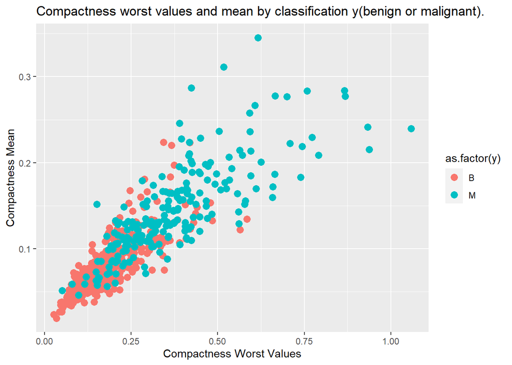